# Week 12

```r
p1 <- "database/detroit.sqlite"
p2 <- "static/solutions/database/detroit.sqlite"

if(dir.exists("static/lectures")){
  model_fit <- readRDS("static/lectures/model_fit.RDS")
  modeldata <- readRDS("static/lectures/modeldata.RDS")
} else {
  base_str <- "https://github.com/erhla/pa470spring2022/raw/main/static/lectures/"
  model_fit <- readRDS(url("https://github.com/erhla/pa470spring2022/raw/main/static/lectures/model_fit.RDS"))
  modeldata <- readRDS(url("https://github.com/erhla/pa470spring2022/raw/main/static/lectures/modeldata.RDS"))
}


modeldata <- modeldata %>%
  select(sp_log, parcel_num, Neighborhood, ASSESSEDVALUE,
    total_squa, heightcat, extcat, has_garage,
    has_basement, bathcat, total_floo, pct_over_50,
    foreclosures_per_prop,
    year_built, GEOID, sale_date) %>%
  mutate(across(where(is.character), as.factor))
```

# 1 Ch 18, Explaining Models/Predictions

Why do our models make the predictions they do? Model explanations can shed some light on this. For this assignment, I have saved my model data and fitted model from the Detroit Assessment project.

## 1.1 Techniques

- `vip` functions when we want to use *model-based* methods that take advantage of model structure (and are often faster), and
- `DALEX` functions when we want to use *model-agnostic* methods that can be applied to any model.

Let’s look at building a model-agnostic explainer for our model.

```r
library(DALEXtra)
sales <- modeldata %>% filter(!is.na(sp_log), year_built != 0)

explain_reg <- explain_tidymodels(
  model_fit,
  data = sales,
  y = sales$sp_log,
  verbose=TRUE
)
```

```
## Preparation of a new explainer is initiated
##   -> model label       :  workflow  (  default  )
##   -> data              :  4336  rows  16  cols
##   -> data              :  tibble converted into a data.frame
##   -> target variable   :  4336  values
##   -> predict function  :  yhat.workflow  will be used (  default  )
##   -> predicted values  :  No value for predict function target column. (  default  )
##   -> model_info        :  package tidymodels , ver. 1.0.0 , task regression (  default  )
##   -> predicted values  :  numerical, min =  3.836263 , mean =  4.510255 , max =  5.634867
##   -> residual function :  difference between y and yhat (  default  )
##   -> residuals         :  numerical, min =  -1.258597 , mean =  -0.1755897 , max =  0.6319306
##   A new explainer has been created!
```

## 1.2 Local Explanations

A local explanation will provide information about a prediction for a single observation.

```r
targ <- modeldata %>% filter(parcel_num == '22027164.')

targ %>% t() %>%
  kableExtra::kable() %>%
  kableExtra::kable_material(c("striped", "hover"))
```

sp_log

4.845098

parcel_num

Neighborhood

0033A

ASSESSEDVALUE

19900

total_squa

4792

heightcat

2

extcat

3

has_garage

1

has_basement

1

bathcat

1

total_floo

1462

pct_over_50

0.6666667

foreclosures_per_prop

0.1332053

year_built

1941

GEOID

26163539400

sale_date

2019-01-01

```r
preds <- predict_parts(explainer = explain_reg,
              new_observation = targ)

preds
```

| variable | contribution | variable_name | variable_value | cumulative | sign | position | label |
| --- | --- | --- | --- | --- | --- | --- | --- |
| intercept | 4.51025487 | intercept | 1 | 4.510255 | 1 | 18 | workflow |
| ASSESSEDVALUE = 19900 | 0.11285294 | ASSESSEDVALUE | 19900 | 4.623108 | 1 | 17 | workflow |
| total_floo = 1462 | 0.02634718 | total_floo | 1462 | 4.649455 | 1 | 16 | workflow |
| foreclosures_per_prop = 0.133205251360871 | 0.03825646 | foreclosures_per_prop | 0.133205251360871 | 4.687711 | 1 | 15 | workflow |
| year_built = 1941 | 0.01722600 | year_built | 1941 | 4.704937 | 1 | 14 | workflow |
| total_squa = 4792 | 0.01508530 | total_squa | 4792 | 4.720023 | 1 | 13 | workflow |
| pct_over_50 = 0.666666666666667 | -0.01248178 | pct_over_50 | 0.666666666666667 | 4.707541 | -1 | 12 | workflow |
| sp_log = 4.84509804001426 | 0.00000000 | sp_log | 4.84509804001426 | 4.707541 | 0 | 11 | workflow |
| parcel_num = 127120 | 0.00000000 | parcel_num | 127120 | 4.707541 | 0 | 10 | workflow |
| Neighborhood = 1 | 0.00000000 | Neighborhood | 1 | 4.707541 | 0 | 9 | workflow |

[output cut: 8 more lines]

It is pretty expensive to compute important features. Best practice is to use Shapley Additive Explanations (SHAP) “where the average contributions of features are computed under different combinations or “coalitions” of feature orderings.”

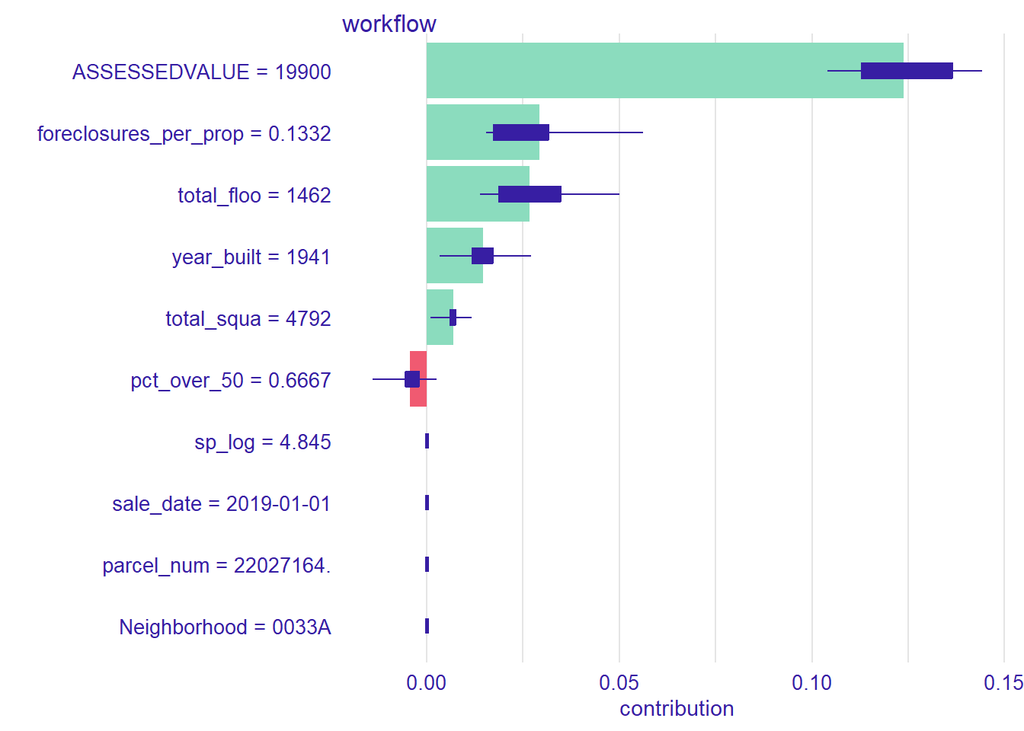

```r
preds_shap <-
  predict_parts(
    explainer = explain_reg,
    new_observation = targ,
    type = "shap",
    B = 20
  )

plot(preds_shap)
```

Let’s look at another property.

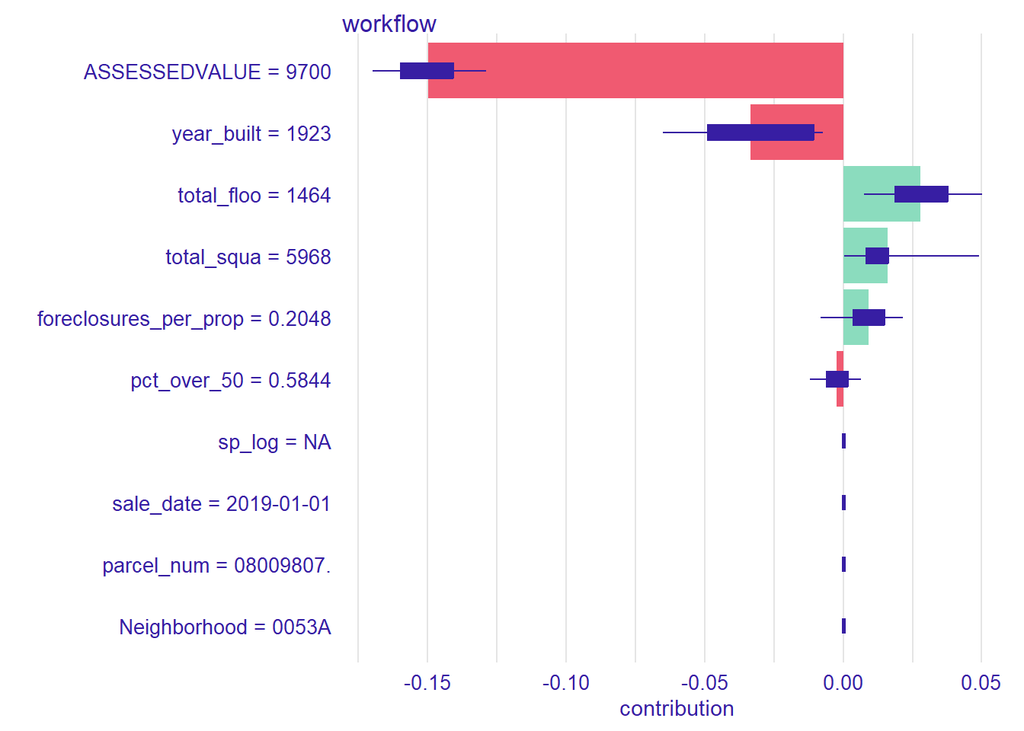

```r
targ2 <- modeldata %>% filter(parcel_num == '08009807.')

predict_parts(
  explainer = explain_reg,
  new_observation = targ2,
  type = "shap",
  B = 20
) %>% plot()
```

The explanation is local, so each data point has unique contributions.

## 1.3 Global Explanation

Also called variable importance. These explanations can help us understand which features are most important in driving predictions aggregated over all the data.

One way to compute vip is to permute the features and measure how much worse the model is when the data is fitted before/after shuffling.

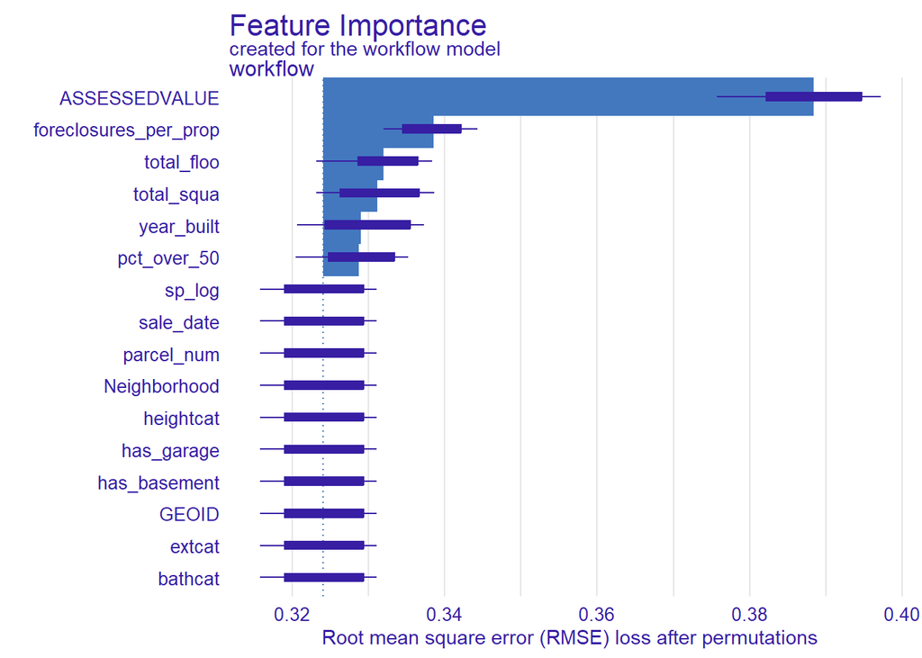

```r
vip_model <- model_parts(explain_reg,
                    loss_function = loss_root_mean_square)

plot(vip_model)
```

Mirroring Figure 18.4 from the textbook.

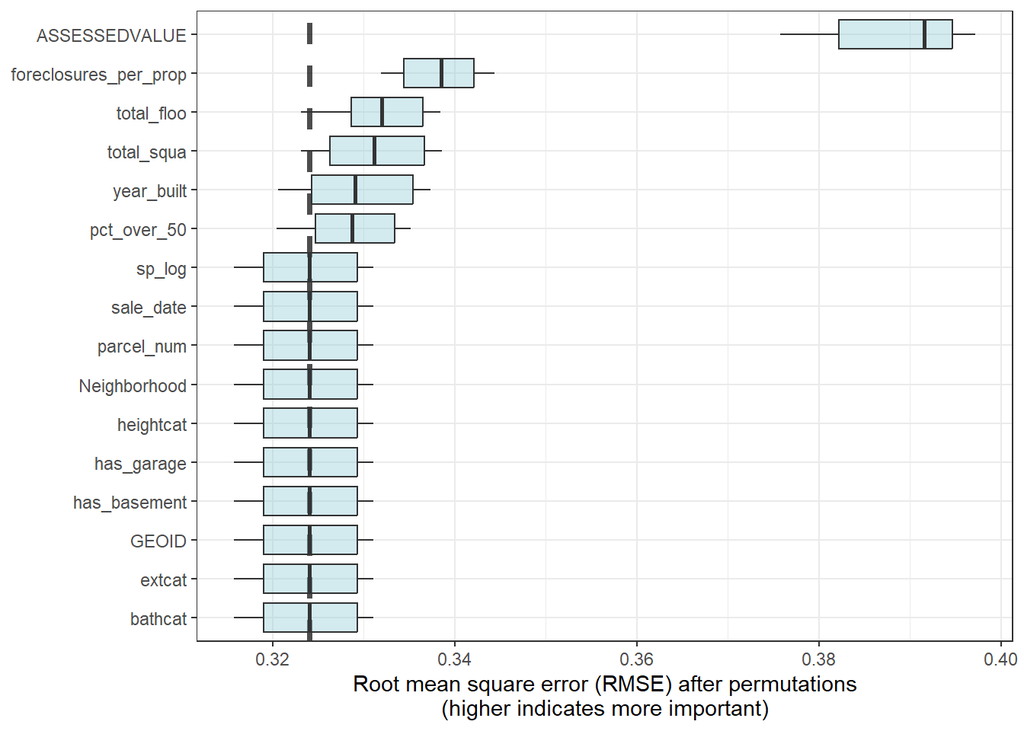

```r
ggplot_imp <- function(...) {
  obj <- list(...)
  metric_name <- attr(obj[[1]], "loss_name")
  metric_lab <- paste(metric_name,
                      "after permutations\n(higher indicates more important)")

  full_vip <- bind_rows(obj) %>%
    filter(variable != "_baseline_")

  perm_vals <- full_vip %>%
    filter(variable == "_full_model_") %>%
    group_by(label) %>%
    summarise(dropout_loss = mean(dropout_loss))

  p <- full_vip %>%
    filter(variable != "_full_model_") %>%
    mutate(variable = fct_reorder(variable, dropout_loss)) %>%
    ggplot(aes(dropout_loss, variable))
  if(length(obj) > 1) {
    p <- p +
      facet_wrap(vars(label)) +
      geom_vline(data = perm_vals, aes(xintercept = dropout_loss, color = label),
                 size = 1.4, lty = 2, alpha = 0.7) +
      geom_boxplot(aes(color = label, fill = label), alpha = 0.2)
  } else {
    p <- p +
      geom_vline(data = perm_vals, aes(xintercept = dropout_loss),
                 size = 1.4, lty = 2, alpha = 0.7) +
      geom_boxplot(fill = "#91CBD765", alpha = 0.4)

  }
  p +
    theme(legend.position = "none") +
    labs(x = metric_lab,
         y = NULL,  fill = NULL,  color = NULL)
}

ggplot_imp(vip_model)
```

## 1.4 Partial Dependence

We can also build global model explanations by aggregating local explanations with partial dependence profiles (imagine a derivative).

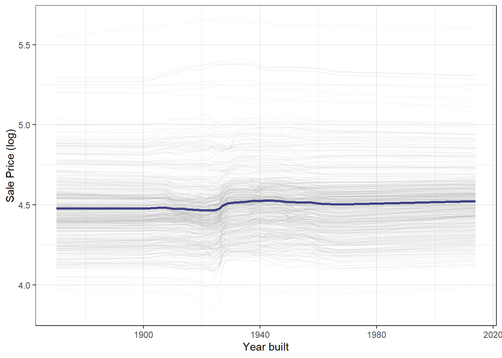

```r
ggplot_pdp <- function(obj, x) {

  p <-
    as_tibble(obj$agr_profiles) %>%
    mutate(`_label_` = stringr::str_remove(`_label_`, "^[^_]*_")) %>%
    ggplot(aes(`_x_`, `_yhat_`)) +
    geom_line(data = as_tibble(obj$cp_profiles),
              aes(x = {{ x }}, group = `_ids_`),
              size = 0.5, alpha = 0.05, color = "gray50")

  num_colors <- n_distinct(obj$agr_profiles$`_label_`)

  if (num_colors > 1) {
    p <- p + geom_line(aes(color = `_label_`), size = 1.2, alpha = 0.8)
  } else {
    p <- p + geom_line(color = "midnightblue", size = 1.2, alpha = 0.8)
  }

  p
}

pdp_age <- model_profile(explain_reg,
                         N=500,
                         variable = "year_built")

ggplot_pdp(pdp_age, year_built)  +
  labs(x = "Year built",
       y = "Sale Price (log)",
       color = NULL)
```

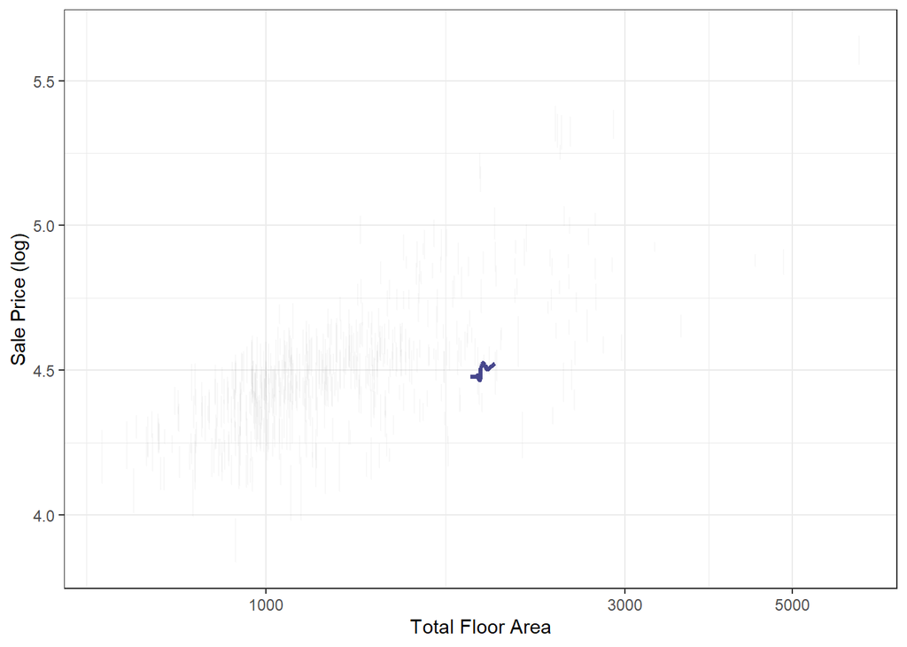

```r
pdp_floor <- model_profile(explain_reg,
                         N=500,
                         variable = "total_floo")

ggplot_pdp(pdp_age, total_floo)  +
  scale_x_log10() +
  labs(x = "Total Floor Area",
       y = "Sale Price (log)",
       color = NULL)
```